# procesing

YEVGENIIA

2024-09-23

## Procesing

**1. Instilling packages**

packages <- c(“tidyverse”, “here”, “janitor”, “lubridate”, “skimr”, “readr”, “dplyr”) invisible(lapply(packages, function(x) if (!require(x, character.only = TRUE)) install.packages(x)))

library(tidyverse) library(here) library(janitor) library(lubridate) library(skimr) library(readr) library(dplyr)

**2. Import csv files**

For analysis we use data for April and May 2016 because this period contains more parameters for assessing trends.

Сheck files list and save it in txt format

```r
library(here)
# Get a list of all files in the DATA folder
file_list <- list.files(path = here("DATA"), full.names = TRUE)
file_list <- file_list[file.exists(file_list)]

# Print the list of files on the screen
print(file_list)
```

```
##  [1] "/cloud/project/DATA/dailyActivity_merged.csv"
##  [2] "/cloud/project/DATA/dailyCalories_merged.csv"
##  [3] "/cloud/project/DATA/dailyIntensities_merged.csv"
##  [4] "/cloud/project/DATA/dailySteps_merged.csv"
##  [5] "/cloud/project/DATA/heartrate_seconds_merged.csv"
##  [6] "/cloud/project/DATA/hourlyCalories_merged.csv"
##  [7] "/cloud/project/DATA/hourlyData_merged.csv"
##  [8] "/cloud/project/DATA/hourlyIntensities_merged.csv"
##  [9] "/cloud/project/DATA/hourlySteps_merged.csv"
## [10] "/cloud/project/DATA/minuteCaloriesNarrow_merged.csv"
## [11] "/cloud/project/DATA/minuteCaloriesWide_merged.csv"
## [12] "/cloud/project/DATA/minuteIntensitiesNarrow_merged.csv"
## [13] "/cloud/project/DATA/minuteIntensitiesWide_merged.csv"
## [14] "/cloud/project/DATA/minuteMETsNarrow_merged.csv"
## [15] "/cloud/project/DATA/minuteSleep_merged.csv"
## [16] "/cloud/project/DATA/minuteStepsNarrow_merged.csv"
## [17] "/cloud/project/DATA/minuteStepsWide_merged.csv"
## [18] "/cloud/project/DATA/sleepDay_merged.csv"
## [19] "/cloud/project/DATA/weightLogInfo_merged.csv"
```

```r
# Save the list of files to a text file
writeLines(file_list, "file_list.txt")

# Load all CSV files into a list, skipping non-existent files
data_list <- lapply(file_list[file.exists(file_list)], read.csv)

# Assign names to data.frames based on file names
names(data_list) <- basename(file_list[file.exists(file_list)])
```

**3. Extract and compare column names**

```r
# Extract column names for each file
column_names <- lapply(data_list, names)

# Print column names for each file
for (name in names(column_names)) {
  cat("Columns in", name, ":\n")
  print(column_names[[name]])
  cat("\n")
}
```

```
## Columns in dailyActivity_merged.csv :
##  [1] "Id"                       "ActivityDate"
##  [3] "TotalSteps"               "TotalDistance"
##  [5] "TrackerDistance"          "LoggedActivitiesDistance"
##  [7] "VeryActiveDistance"       "ModeratelyActiveDistance"
##  [9] "LightActiveDistance"      "SedentaryActiveDistance"
## [11] "VeryActiveMinutes"        "FairlyActiveMinutes"
## [13] "LightlyActiveMinutes"     "SedentaryMinutes"
## [15] "Calories"
##
## Columns in dailyCalories_merged.csv :
## [1] "Id"          "ActivityDay" "Calories"
##
## Columns in dailyIntensities_merged.csv :
##  [1] "Id"                       "ActivityDay"
##  [3] "SedentaryMinutes"         "LightlyActiveMinutes"
##  [5] "FairlyActiveMinutes"      "VeryActiveMinutes"
##  [7] "SedentaryActiveDistance"  "LightActiveDistance"
##  [9] "ModeratelyActiveDistance" "VeryActiveDistance"
##
## Columns in dailySteps_merged.csv :
## [1] "Id"          "ActivityDay" "StepTotal"
##
## Columns in heartrate_seconds_merged.csv :
## [1] "Id"    "Time"  "Value"
##
## Columns in hourlyCalories_merged.csv :
## [1] "Id"           "ActivityHour" "Calories"
##
## Columns in hourlyData_merged.csv :
## [1] "Id"               "ActivityHour"     "Calories"         "TotalIntensity"
## [5] "AverageIntensity" "StepTotal"
##
## Columns in hourlyIntensities_merged.csv :
## [1] "Id"               "ActivityHour"     "TotalIntensity"   "AverageIntensity"
##
## Columns in hourlySteps_merged.csv :
## [1] "Id"           "ActivityHour" "StepTotal"
##
## Columns in minuteCaloriesNarrow_merged.csv :
```

[output cut: 51 more lines]

```
## [31] "Steps28"      "Steps29"      "Steps30"      "Steps31"      "Steps32"
## [36] "Steps33"      "Steps34"      "Steps35"      "Steps36"      "Steps37"
## [41] "Steps38"      "Steps39"      "Steps40"      "Steps41"      "Steps42"
## [46] "Steps43"      "Steps44"      "Steps45"      "Steps46"      "Steps47"
## [51] "Steps48"      "Steps49"      "Steps50"      "Steps51"      "Steps52"
## [56] "Steps53"      "Steps54"      "Steps55"      "Steps56"      "Steps57"
## [61] "Steps58"      "Steps59"
##
## Columns in sleepDay_merged.csv :
## [1] "Id"                 "SleepDay"           "TotalSleepRecords"
## [4] "TotalMinutesAsleep" "TotalTimeInBed"
##
## Columns in weightLogInfo_merged.csv :
## [1] "Id"             "Date"           "WeightKg"       "WeightPounds"
## [5] "Fat"            "BMI"            "IsManualReport" "LogId"
```

**4. Check and select files based on the number of unique IDs**

```r
# Compare column names across all files
common_columns <- Reduce(intersect, column_names)
cat("Common columns across all files:\n")
```

```
## Common columns across all files:
```

```r
print(common_columns)
```

```
## [1] "Id"
```

```r
# Function to count the number of unique IDs in a file
count_unique_ids <- function(file_path) {
  if (file.exists(file_path)) {
    print(paste("Processing:", file_path))                                       # Debug: Check the file being processed
    data <- tryCatch(read_csv(file_path, col_types = cols_only(Id = col_character())),
                     error = function(e) {
                       print(paste("Error reading file:", file_path))            # Debug: Log errors
                       NULL
                     })
    if (!is.null(data)) {
      print(paste("Unique IDs in", file_path, ":", length(unique(data$Id))))     # Debug: Show count
      return(length(unique(data$Id)))
    }
  }
  return(0)
}

# Filter files that have more than 33 unique IDs
files_with_enough_ids <- file_list[sapply(file_list, count_unique_ids) >= 33]
```

[output not shown]

[output cut: 23 more lines]

```r
# Print the names of files that meet the condition
print(files_with_enough_ids)
```

```
## character(0)
```

**5. Merge the datasets containing time-related information**

After examining the column names, merging the three datasets containing time-related information into a single dataset using the “Id” and “ActivityHour” columns.

```r
library(dplyr)
# Load hourly data from three CSV files
hourly_calories <- read.csv(here("DATA", "hourlyCalories_merged.csv"))           # Data on hourly calorie burn
hourly_intensities <- read.csv(here("DATA", "hourlyIntensities_merged.csv"))     # Data on hourly activity intensities
hourly_steps <- read.csv(here("DATA", "hourlySteps_merged.csv"))                 # Data on hourly step counts

# Merge the datasets by 'Id' and 'ActivityHour' columns
# The result will include only rows with matching 'Id' and 'ActivityHour' across all three datasets
# Merge with hourly intensities
merged_hourly_data <- hourly_calories |>
  inner_join(hourly_intensities, by = c("Id", "ActivityHour")) |>
  # Merge with hourly steps
  inner_join(hourly_steps, by = c("Id", "ActivityHour"))

# Save the merged dataset as a new CSV file
write.csv(merged_hourly_data, here("DATA", "hourlyData_merged.csv"), row.names = FALSE)  # Save without row numbers

# Print a message indicating successful merging
cat("Data merged successfully into 'hourlyData_merged.csv'")
```

```
## Data merged successfully into 'hourlyData_merged.csv'
```

**7. Convert the various dates and times in ‘hourlyData_merged’ to the correct format and add DayOfWeek column**

```r
# Load necessary libraries
library(dplyr)
library(lubridate)
library(readr)
library(here)

# Load the raw merged hourly data from the CSV file
hourly_data_raw <- read.csv(here("DATA", "hourlyData_merged.csv"))

# Convert the 'ActivityHour' column from a character string to a datetime object
# Using the 'mdy_hms' function from the 'lubridate' package to parse dates in "Month-Day-Year Hour:Minute:Second" format
hourly_data_raw$ActivityHour <- mdy_hms(hourly_data_raw$ActivityHour)

# Extract the day of the week from the 'ActivityHour' datetime column
# 'label = TRUE' ensures the result is a factor with day names, and 'abbr = FALSE' ensures full names are used
hourly_data_raw$DayOfWeek <- wday(hourly_data_raw$ActivityHour, label = TRUE, abbr = FALSE, week_start = 1)

# Display the first few rows of the processed data to verify the transformations
head(hourly_data_raw)
```

```
##           Id        ActivityHour Calories TotalIntensity AverageIntensity
## 1 1503960366 2016-04-12 00:00:00       81             20         0.333333
## 2 1503960366 2016-04-12 01:00:00       61              8         0.133333
## 3 1503960366 2016-04-12 02:00:00       59              7         0.116667
## 4 1503960366 2016-04-12 03:00:00       47              0         0.000000
## 5 1503960366 2016-04-12 04:00:00       48              0         0.000000
## 6 1503960366 2016-04-12 05:00:00       48              0         0.000000
##   StepTotal DayOfWeek
## 1       373   Tuesday
## 2       160   Tuesday
## 3       151   Tuesday
## 4         0   Tuesday
## 5         0   Tuesday
## 6         0   Tuesday
```

**8. Read and сheck files with daily data**

```r
# Reading the files
daily_activity <- read.csv("DATA/dailyActivity_merged.csv")
daily_calories <- read.csv("DATA/dailyCalories_merged.csv")
daily_intensities <- read.csv("DATA/dailyIntensities_merged.csv")
daily_steps <- read.csv("DATA/dailySteps_merged.csv")

# Display the first 5 rows of each file
head(daily_activity, 5)
```

```
##           Id ActivityDate TotalSteps TotalDistance TrackerDistance
## 1 1503960366    4/12/2016      13162          8.50            8.50
## 2 1503960366    4/13/2016      10735          6.97            6.97
## 3 1503960366    4/14/2016      10460          6.74            6.74
## 4 1503960366    4/15/2016       9762          6.28            6.28
## 5 1503960366    4/16/2016      12669          8.16            8.16
##   LoggedActivitiesDistance VeryActiveDistance ModeratelyActiveDistance
## 1                        0               1.88                     0.55
## 2                        0               1.57                     0.69
## 3                        0               2.44                     0.40
## 4                        0               2.14                     1.26
## 5                        0               2.71                     0.41
##   LightActiveDistance SedentaryActiveDistance VeryActiveMinutes
## 1                6.06                       0                25
## 2                4.71                       0                21
## 3                3.91                       0                30
## 4                2.83                       0                29
## 5                5.04                       0                36
##   FairlyActiveMinutes LightlyActiveMinutes SedentaryMinutes Calories
## 1                  13                  328              728     1985
## 2                  19                  217              776     1797
## 3                  11                  181             1218     1776
## 4                  34                  209              726     1745
## 5                  10                  221              773     1863
```

```r
head(daily_calories, 5)
```

```
##           Id ActivityDay Calories
## 1 1503960366   4/12/2016     1985
## 2 1503960366   4/13/2016     1797
## 3 1503960366   4/14/2016     1776
## 4 1503960366   4/15/2016     1745
## 5 1503960366   4/16/2016     1863
```

```r
head(daily_intensities, 5)
```

```
##           Id ActivityDay SedentaryMinutes LightlyActiveMinutes
## 1 1503960366   4/12/2016              728                  328
## 2 1503960366   4/13/2016              776                  217
## 3 1503960366   4/14/2016             1218                  181
## 4 1503960366   4/15/2016              726                  209
## 5 1503960366   4/16/2016              773                  221
##   FairlyActiveMinutes VeryActiveMinutes SedentaryActiveDistance
## 1                  13                25                       0
## 2                  19                21                       0
## 3                  11                30                       0
## 4                  34                29                       0
## 5                  10                36                       0
##   LightActiveDistance ModeratelyActiveDistance VeryActiveDistance
## 1                6.06                     0.55               1.88
## 2                4.71                     0.69               1.57
## 3                3.91                     0.40               2.44
## 4                2.83                     1.26               2.14
## 5                5.04                     0.41               2.71
```

```r
head(daily_steps, 5)
```

```
##           Id ActivityDay StepTotal
## 1 1503960366   4/12/2016     13162
## 2 1503960366   4/13/2016     10735
## 3 1503960366   4/14/2016     10460
## 4 1503960366   4/15/2016      9762
## 5 1503960366   4/16/2016     12669
```

```r
# View the column names for each file
colnames(daily_activity)
```

```
##  [1] "Id"                       "ActivityDate"
##  [3] "TotalSteps"               "TotalDistance"
##  [5] "TrackerDistance"          "LoggedActivitiesDistance"
##  [7] "VeryActiveDistance"       "ModeratelyActiveDistance"
##  [9] "LightActiveDistance"      "SedentaryActiveDistance"
## [11] "VeryActiveMinutes"        "FairlyActiveMinutes"
## [13] "LightlyActiveMinutes"     "SedentaryMinutes"
## [15] "Calories"
```

```r
colnames(daily_calories)
```

```
## [1] "Id"          "ActivityDay" "Calories"
```

```r
colnames(daily_intensities)
```

```
##  [1] "Id"                       "ActivityDay"
##  [3] "SedentaryMinutes"         "LightlyActiveMinutes"
##  [5] "FairlyActiveMinutes"      "VeryActiveMinutes"
##  [7] "SedentaryActiveDistance"  "LightActiveDistance"
##  [9] "ModeratelyActiveDistance" "VeryActiveDistance"
```

```r
colnames(daily_steps)
```

```
## [1] "Id"          "ActivityDay" "StepTotal"
```

‘daily_activity’ has all columns from all file data, so chose it for father analyse.

**9. Convert ActivityDate to Date format Add the DayOfWeek column**

```r
library(lubridate)

# Convert ActivityDate to Date format if necessary
daily_activity$ActivityDate <- as.Date(daily_activity$ActivityDate, format = "%m/%d/%Y")

# Add the DayOfWeek column as numeric (1=Sunday, 2=Monday, ..., 7=Saturday)
daily_activity$DayOfWeek <- wday(daily_activity$ActivityDate, label = FALSE, week_start = 1)

# Convert DayOfWeek to text (1=Sunday, ..., 7=Saturday)
days <- c("Sunday", "Monday", "Tuesday", "Wednesday", "Thursday", "Friday", "Saturday")
daily_activity$DayOfWeekText <- days[daily_activity$DayOfWeek]

# View the first 5 rows to confirm the change
head(daily_activity, 5)
```

[output not shown]

**10. Clean data ‘hourly_data_row’ and ‘daily_activity’**

1. Check for Missing Values (NA)

```r
# Check for missing values in the entire dataset
sum(is.na(daily_activity))   # For daily_activity
```

```
## [1] 0
```

```r
sum(is.na(hourly_data_raw))  # For hourly_data_raw
```

```
## [1] 0
```

```r
# Check for missing values per column
colSums(is.na(daily_activity))
```

```
##                       Id             ActivityDate               TotalSteps
##                        0                        0                        0
##            TotalDistance          TrackerDistance LoggedActivitiesDistance
##                        0                        0                        0
##       VeryActiveDistance ModeratelyActiveDistance      LightActiveDistance
##                        0                        0                        0
##  SedentaryActiveDistance        VeryActiveMinutes      FairlyActiveMinutes
##                        0                        0                        0
##     LightlyActiveMinutes         SedentaryMinutes                 Calories
##                        0                        0                        0
##                DayOfWeek            DayOfWeekText
##                        0                        0
```

```r
colSums(is.na(hourly_data_raw))
```

```
##               Id     ActivityHour         Calories   TotalIntensity
##                0                0                0                0
## AverageIntensity        StepTotal        DayOfWeek
##                0                0                0
```

```r
# Show rows with missing values
daily_activity[!complete.cases(daily_activity), ]
```

```
##  [1] Id                       ActivityDate             TotalSteps
##  [4] TotalDistance            TrackerDistance          LoggedActivitiesDistance
##  [7] VeryActiveDistance       ModeratelyActiveDistance LightActiveDistance
## [10] SedentaryActiveDistance  VeryActiveMinutes        FairlyActiveMinutes
## [13] LightlyActiveMinutes     SedentaryMinutes         Calories
## [16] DayOfWeek                DayOfWeekText
## <0 rows> (or 0-length row.names)
```

```r
hourly_data_raw[!complete.cases(hourly_data_raw), ]
```

```
## [1] Id               ActivityHour     Calories         TotalIntensity
## [5] AverageIntensity StepTotal        DayOfWeek
## <0 rows> (or 0-length row.names)
```

2. Remove or Replace Missing Values

```r
# Remove rows with missing values
daily_activity_clean <- na.omit(daily_activity)
hourly_data_clean <- na.omit(hourly_data_raw)

# Replace missing values with 0 (or another value)
daily_activity[is.na(daily_activity)] <- 0
hourly_data_raw[is.na(hourly_data_raw)] <- 0
```

3. Check for Duplicates

```r
# Find duplicates
sum(duplicated(daily_activity))   # For daily_activity
```

```
## [1] 0
```

```r
sum(duplicated(hourly_data_raw))  # For hourly_data_raw
```

```
## [1] 0
```

```r
# View duplicate rows
daily_activity[duplicated(daily_activity), ]
```

```
##  [1] Id                       ActivityDate             TotalSteps
##  [4] TotalDistance            TrackerDistance          LoggedActivitiesDistance
##  [7] VeryActiveDistance       ModeratelyActiveDistance LightActiveDistance
## [10] SedentaryActiveDistance  VeryActiveMinutes        FairlyActiveMinutes
## [13] LightlyActiveMinutes     SedentaryMinutes         Calories
## [16] DayOfWeek                DayOfWeekText
## <0 rows> (or 0-length row.names)
```

```r
hourly_data_raw[duplicated(hourly_data_raw), ]
```

```
## [1] Id               ActivityHour     Calories         TotalIntensity
## [5] AverageIntensity StepTotal        DayOfWeek
## <0 rows> (or 0-length row.names)
```

```r
# Remove duplicate rows
daily_activity <- daily_activity[!duplicated(daily_activity), ]
hourly_data_raw <- hourly_data_raw[!duplicated(hourly_data_raw), ]
```

4. Check Data Types and Correct Formats

```r
# Check the structure of the dataset
str(daily_activity)
```

```
## 'data.frame':    940 obs. of  17 variables:
##  $ Id                      : num  1.5e+09 1.5e+09 1.5e+09 1.5e+09 1.5e+09 ...
##  $ ActivityDate            : Date, format: "2016-04-12" "2016-04-13" ...
##  $ TotalSteps              : int  13162 10735 10460 9762 12669 9705 13019 15506 10544 9819 ...
##  $ TotalDistance           : num  8.5 6.97 6.74 6.28 8.16 ...
##  $ TrackerDistance         : num  8.5 6.97 6.74 6.28 8.16 ...
##  $ LoggedActivitiesDistance: num  0 0 0 0 0 0 0 0 0 0 ...
##  $ VeryActiveDistance      : num  1.88 1.57 2.44 2.14 2.71 ...
##  $ ModeratelyActiveDistance: num  0.55 0.69 0.4 1.26 0.41 ...
##  $ LightActiveDistance     : num  6.06 4.71 3.91 2.83 5.04 ...
##  $ SedentaryActiveDistance : num  0 0 0 0 0 0 0 0 0 0 ...
##  $ VeryActiveMinutes       : int  25 21 30 29 36 38 42 50 28 19 ...
##  $ FairlyActiveMinutes     : int  13 19 11 34 10 20 16 31 12 8 ...
##  $ LightlyActiveMinutes    : int  328 217 181 209 221 164 233 264 205 211 ...
##  $ SedentaryMinutes        : int  728 776 1218 726 773 539 1149 775 818 838 ...
##  $ Calories                : int  1985 1797 1776 1745 1863 1728 1921 2035 1786 1775 ...
##  $ DayOfWeek               : num  2 3 4 5 6 7 1 2 3 4 ...
##  $ DayOfWeekText           : chr  "Monday" "Tuesday" "Wednesday" "Thursday" ...
```

```r
str(hourly_data_raw)
```

```
## 'data.frame':    22099 obs. of  7 variables:
##  $ Id              : num  1.5e+09 1.5e+09 1.5e+09 1.5e+09 1.5e+09 ...
##  $ ActivityHour    : POSIXct, format: "2016-04-12 00:00:00" "2016-04-12 01:00:00" ...
##  $ Calories        : int  81 61 59 47 48 48 48 47 68 141 ...
##  $ TotalIntensity  : int  20 8 7 0 0 0 0 0 13 30 ...
##  $ AverageIntensity: num  0.333 0.133 0.117 0 0 ...
##  $ StepTotal       : int  373 160 151 0 0 0 0 0 250 1864 ...
##  $ DayOfWeek       : Ord.factor w/ 7 levels "Monday"<"Tuesday"<..: 2 2 2 2 2 2 2 2 2 2 ...
```

```r
# Convert columns to correct data types (example for date format)
daily_activity$ActivityDate <- as.Date(daily_activity$ActivityDate, format = "%m/%d/%Y")
hourly_data_raw$ActivityHour <- as.POSIXct(hourly_data_raw$ActivityHour, format = "%m/%d/%Y %I:%M:%S %p", tz = "UTC")
```

5. Check for Outliers or Unusual Values

```r
# Summary statistics to detect outliers
summary(daily_activity)
```

```
##        Id             ActivityDate          TotalSteps    TotalDistance
##  Min.   :1.504e+09   Min.   :2016-04-12   Min.   :    0   Min.   : 0.000
##  1st Qu.:2.320e+09   1st Qu.:2016-04-19   1st Qu.: 3790   1st Qu.: 2.620
##  Median :4.445e+09   Median :2016-04-26   Median : 7406   Median : 5.245
##  Mean   :4.855e+09   Mean   :2016-04-26   Mean   : 7638   Mean   : 5.490
##  3rd Qu.:6.962e+09   3rd Qu.:2016-05-04   3rd Qu.:10727   3rd Qu.: 7.713
##  Max.   :8.878e+09   Max.   :2016-05-12   Max.   :36019   Max.   :28.030
##  TrackerDistance  LoggedActivitiesDistance VeryActiveDistance
##  Min.   : 0.000   Min.   :0.0000           Min.   : 0.000
##  1st Qu.: 2.620   1st Qu.:0.0000           1st Qu.: 0.000
##  Median : 5.245   Median :0.0000           Median : 0.210
##  Mean   : 5.475   Mean   :0.1082           Mean   : 1.503
##  3rd Qu.: 7.710   3rd Qu.:0.0000           3rd Qu.: 2.053
##  Max.   :28.030   Max.   :4.9421           Max.   :21.920
##  ModeratelyActiveDistance LightActiveDistance SedentaryActiveDistance
##  Min.   :0.0000           Min.   : 0.000      Min.   :0.000000
##  1st Qu.:0.0000           1st Qu.: 1.945      1st Qu.:0.000000
##  Median :0.2400           Median : 3.365      Median :0.000000
##  Mean   :0.5675           Mean   : 3.341      Mean   :0.001606
##  3rd Qu.:0.8000           3rd Qu.: 4.782      3rd Qu.:0.000000
##  Max.   :6.4800           Max.   :10.710      Max.   :0.110000
##  VeryActiveMinutes FairlyActiveMinutes LightlyActiveMinutes SedentaryMinutes
##  Min.   :  0.00    Min.   :  0.00      Min.   :  0.0        Min.   :   0.0
##  1st Qu.:  0.00    1st Qu.:  0.00      1st Qu.:127.0        1st Qu.: 729.8
##  Median :  4.00    Median :  6.00      Median :199.0        Median :1057.5
##  Mean   : 21.16    Mean   : 13.56      Mean   :192.8        Mean   : 991.2
##  3rd Qu.: 32.00    3rd Qu.: 19.00      3rd Qu.:264.0        3rd Qu.:1229.5
##  Max.   :210.00    Max.   :143.00      Max.   :518.0        Max.   :1440.0
##     Calories      DayOfWeek     DayOfWeekText
##  Min.   :   0   Min.   :1.000   Length:940
##  1st Qu.:1828   1st Qu.:2.000   Class :character
##  Median :2134   Median :4.000   Mode  :character
##  Mean   :2304   Mean   :3.918
##  3rd Qu.:2793   3rd Qu.:6.000
##  Max.   :4900   Max.   :7.000
```

```r
summary(hourly_data_raw)
```

```
##        Id             ActivityHour                       Calories
##  Min.   :1.504e+09   Min.   :2016-04-12 00:00:00.00   Min.   : 42.00
##  1st Qu.:2.320e+09   1st Qu.:2016-04-19 01:00:00.00   1st Qu.: 63.00
##  Median :4.445e+09   Median :2016-04-26 06:00:00.00   Median : 83.00
##  Mean   :4.848e+09   Mean   :2016-04-26 11:46:42.58   Mean   : 97.39
##  3rd Qu.:6.962e+09   3rd Qu.:2016-05-03 19:00:00.00   3rd Qu.:108.00
##  Max.   :8.878e+09   Max.   :2016-05-12 15:00:00.00   Max.   :948.00
##
##  TotalIntensity   AverageIntensity   StepTotal           DayOfWeek
##  Min.   :  0.00   Min.   :0.0000   Min.   :    0.0   Monday   :2861
##  1st Qu.:  0.00   1st Qu.:0.0000   1st Qu.:    0.0   Tuesday  :3600
##  Median :  3.00   Median :0.0500   Median :   40.0   Wednesday:3547
##  Mean   : 12.04   Mean   :0.2006   Mean   :  320.2   Thursday :3283
##  3rd Qu.: 16.00   3rd Qu.:0.2667   3rd Qu.:  357.0   Friday   :2997
##  Max.   :180.00   Max.   :3.0000   Max.   :10554.0   Saturday :2915
##                                                      Sunday   :2896
```

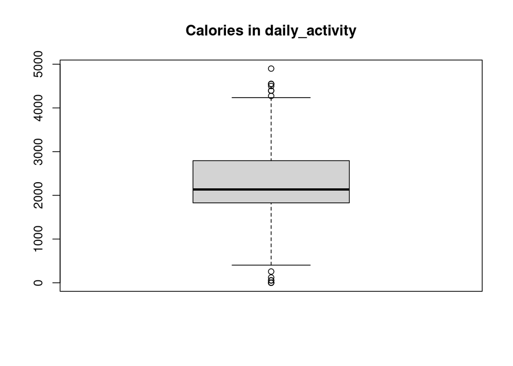

```r
# Boxplot to visualize outliers
boxplot(daily_activity$Calories, main = "Calories in daily_activity")
```

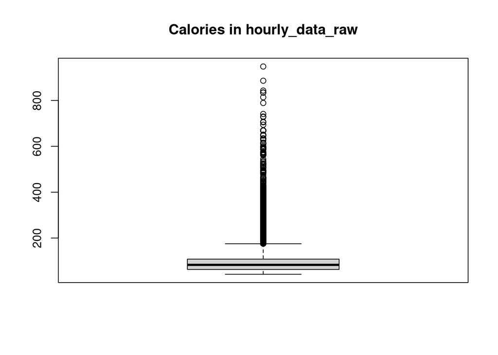

```r
boxplot(hourly_data_raw$Calories, main = "Calories in hourly_data_raw")
```

6. Handle Invalid Formats

```r
# Convert columns to numeric if necessary
daily_activity$Calories <- as.numeric(daily_activity$Calories)
hourly_data_raw$Calories <- as.numeric(hourly_data_raw$Calories)

# Handle non-numeric values (e.g., replace non-numeric values with NA)
daily_activity$Calories[is.na(daily_activity$Calories)] <- 0
hourly_data_raw$Calories[is.na(hourly_data_raw$Calories)] <- 0
```

7. Check for Invalid Date Formats

```r
# Convert to Date format
daily_activity$ActivityDate <- as.Date(daily_activity$ActivityDate, format = "%m/%d/%Y")
hourly_data_raw$ActivityHour <- as.POSIXct(hourly_data_raw$ActivityHour, format = "%m/%d/%Y %I:%M:%S %p")
```

8. Check for Zero or Negative Values in Numeric Columns

```r
# Check for zero or negative values in specific columns
sum(daily_activity$Calories <= 0)
```

```
## [1] 4
```

```r
sum(hourly_data_raw$Calories <= 0)
```

```
## [1] 0
```

check 4 rows where colories <= 0

```r
# Filter rows where Calories <= 0
invalid_calories <- daily_activity[daily_activity$Calories <= 0, ]

# View the filtered rows
print(invalid_calories)
```

```
##             Id ActivityDate TotalSteps TotalDistance TrackerDistance
## 31  1503960366   2016-05-12          0             0               0
## 654 6290855005   2016-05-10          0             0               0
## 818 8253242879   2016-04-30          0             0               0
## 880 8583815059   2016-05-12          0             0               0
##     LoggedActivitiesDistance VeryActiveDistance ModeratelyActiveDistance
## 31                         0                  0                        0
## 654                        0                  0                        0
## 818                        0                  0                        0
## 880                        0                  0                        0
##     LightActiveDistance SedentaryActiveDistance VeryActiveMinutes
## 31                    0                       0                 0
## 654                   0                       0                 0
## 818                   0                       0                 0
## 880                   0                       0                 0
##     FairlyActiveMinutes LightlyActiveMinutes SedentaryMinutes Calories
## 31                    0                    0             1440        0
## 654                   0                    0             1440        0
## 818                   0                    0             1440        0
## 880                   0                    0             1440        0
##     DayOfWeek DayOfWeekText
## 31          4     Wednesday
## 654         2        Monday
## 818         6        Friday
## 880         4     Wednesday
```

we see any activities in other columns, so it should be removed.

```r
daily_activity <- daily_activity[daily_activity$Calories > 0, ]
```

**11. Rename the dataframe from hourly_data_raw to hourly_activity**

```r
# Rename the dataframe from hourly_data_raw to hourly_activity
hourly_activity <- hourly_data_raw
```

**12. Export the data to CSV format for use in Tableau**

```r
write.csv(daily_activity, "daily_activity_cleaned.csv", row.names = FALSE)
write.csv(hourly_activity, "hourly_activity_cleaned.csv", row.names = FALSE)
```